# R Final Project

Lovro Forštner

11 6 2020

## Video Game Sales Project

For my final project in the Data Programming course I chose the data set containing video game sales with data of video game sales in North America, Europe, Japan and the global sales.

This data set contains a list of video games with sales greater than 100,000 copies. It was generated by a scrape of vgchartz.com. I chose this data set because video games are my hobby and I decided it would be interesting to see some of the details like for example which video games sold the most copies in different parts of the world, what are the top video games sold globally and what platforms take up most of the video game market. I found the data set on the website kaggle.com.

### Introduction of the data

The data comes in the csv format and it is called vgames.csv. There are 11 columns and 11493 unique values of video games that were sold. The dataset contains a list of video games with sales greater than 100,000 copies.

Fields include:

- Rank - Ranking of overall sales
- Name - The games name
- Platform - Platform of the games release (i.e. PC,PS4, etc.)
- Year - Year of the game’s release
- Genre - Genre of the game
- Publisher - Publisher of the game
- NA_Sales - Sales in North America (in millions)
- EU_Sales - Sales in Europe (in millions)
- JP_Sales - Sales in Japan (in millions)
- Other_Sales - Sales in the rest of the world (in millions)
- Global_Sales - Total worldwide sales

First I read the .csv file and saved it into the vgsales variable. Here are the first 5 rows with the first 7 columns of the data set where only sales from North America are shown together with the details of the game and the year.

```
##   Rank                     Name Platform Year        Genre Publisher NA_Sales
## 1    1               Wii Sports      Wii 2006       Sports  Nintendo    41.49
## 2    2        Super Mario Bros.      NES 1985     Platform  Nintendo    29.08
## 3    3           Mario Kart Wii      Wii 2008       Racing  Nintendo    15.85
## 4    4        Wii Sports Resort      Wii 2009       Sports  Nintendo    15.75
## 5    5 Pokemon Red/Pokemon Blue       GB 1996 Role-Playing  Nintendo    11.27
```

### Best selling games for individual publishers

Here are the results of the best sold games from unique publishers. These represent the ammount of copies sold for the best game a single publisher produced. It is measured by the global sales. The ggplot represents the difference between how well the best game from different publishers sold globally.

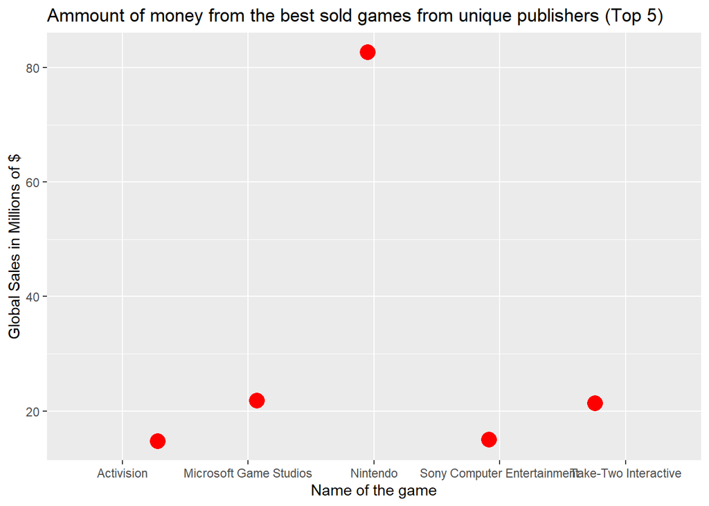

The fact that Wii Sports was bundled with the Wii console in most areas where you could buy this console definitely can’t be ignored. They created a game that was accessible to anyone.

### Best selling GameBoy games

Below is the data for top 5 most sold GameBoy games. It was my first console I got as a child, and Pokemon Red was one of the games I owned. Interestingly enough it is the most sold game worldwide for this platform and the only game that comes close to all global sales is Tetris. Pokemon Red/Pokemon Blue made 31.37 millions of copies followed by Tetris with 30.26 millions of copies.

```
##   Rank                                     Name Platform Year Global_Sales
## 1    5                 Pokemon Red/Pokemon Blue       GB 1996        31.37
## 2    6                                   Tetris       GB 1989        30.26
## 3   13              Pokemon Gold/Pokemon Silver       GB 1999        23.10
## 4   22                         Super Mario Land       GB 1989        18.14
## 5   31 PokĂ©mon Yellow: Special Pikachu Edition       GB 1998        14.64
```

### Video Game Platforms

In the next section I explored the statistics of different platforms the games where made for. I tried to find out what platforms games are made for and which platforms have the best selling video games. Below are listed all the different platforms for video games available in the data set. There are 31 platforms.

```
##  [1] "2600" "3DO"  "3DS"  "DC"   "DS"   "GB"   "GBA"  "GC"   "GEN"  "GG"
## [11] "N64"  "NES"  "NG"   "PC"   "PCFX" "PS"   "PS2"  "PS3"  "PS4"  "PSP"
## [21] "PSV"  "SAT"  "SCD"  "SNES" "TG16" "Wii"  "WiiU" "WS"   "X360" "XB"
## [31] "XOne"
```

### Frequency of platforms for all the games versus the top 1000 games

I wanted to see how the frequency of platforms for all games compares to the platforms for the top 1000 games and if there is any correlation between the amount of games a platform has and the amount of copies the video games for the specific platform sell.

```
## # A tibble: 6 x 3
##   Platform     n percent
##   <fct>    <int>   <dbl>
## 1 PS2        164    16.4
## 2 X360       131    13.1
## 3 PS3        120    12
## 4 PS          82     8.2
## 5 Wii         78     7.8
## 6 DS          67     6.7
```

```
## # A tibble: 6 x 3
##   Platform     n percent
##   <fct>    <int>   <dbl>
## 1 DS        2163   13.0
## 2 PS2       2161   13.0
## 3 PS3       1329    8.01
## 4 Wii       1325    7.98
## 5 X360      1265    7.62
## 6 PSP       1213    7.31
```

#### Frequency of platforms for all the games

First I checked out the percentage of platforms for all the video games available in the data set. Below is the graph for the frequency of platforms of all the games in the data set.

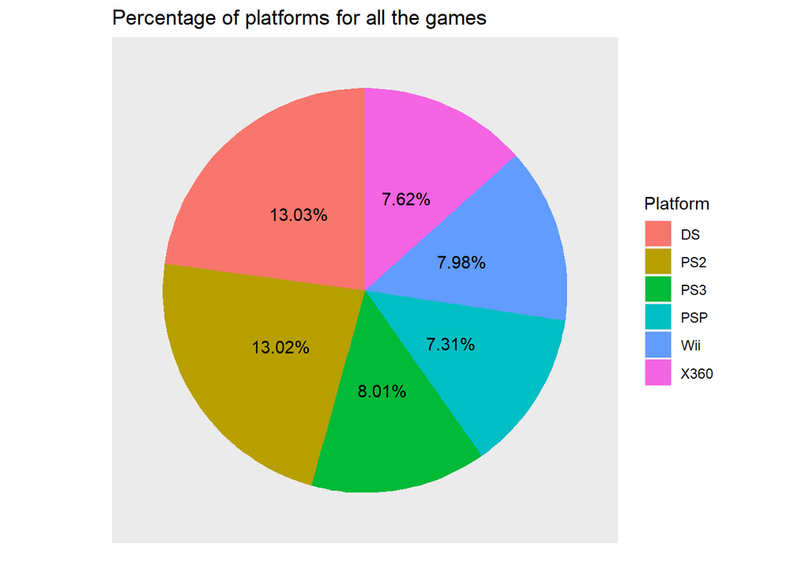

#### Frequency of platforms for the top 1000 games

Then I only checked the top 1000 most globally sold games and checked the percentage of platforms. Below is the graph for the frequency of platforms the top 1000 games in the data set.

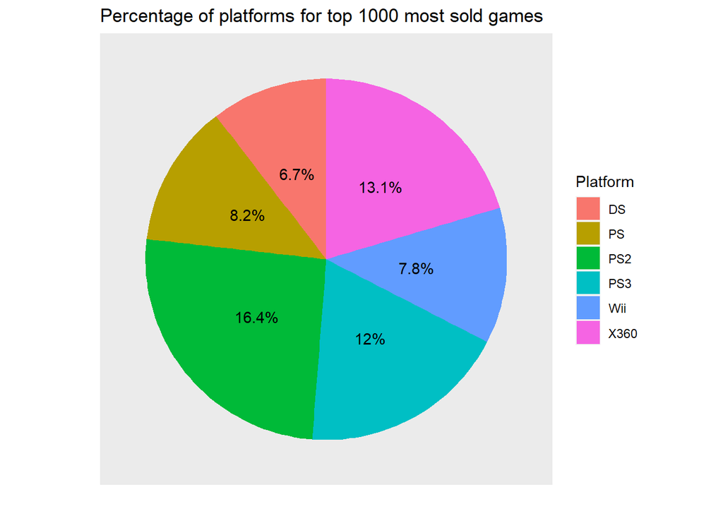

#### Differences in platform percentages

It’s interesting that even though XboX360 is not at the top when you consider all games with 7.62% of all games but when you look at the top 1000 most sold games it’s in the second place not that far behind Playstation 2 with 13.1% games made for the Xbox360 platform.

### Most successful year for video game publishers and developers

I wanted to find out in which year video game publishers made the most money.

Here are the results of the top 5 years:

```
## # A tibble: 5 x 2
##   Year  `Total Sales`
##   <fct>         <dbl>
## 1 2008           679.
## 2 2009           667.
## 3 2007           611.
## 4 2010           600.
## 5 2006           521.
```

### Best years for game publishers

I would have thought that with the improvement of game developing and the amount of new titles coming in every year the result would be more towards the last years (2017 in the data set) but I was surprised to see that a decade ago game publishers made more money than they do today.

Below is a graph showing the global sales for the top 5 years in which game publishers made the most amount of money:

[figure not shown]

After I discovered the statistics for most sales in a single year I wanted to find out if there was more games made in the years that brought the most amount of money.

```
## # A tibble: 7 x 3
## # Groups:   Year [7]
##   Year  `"Year"` `Ammount of games released`
##   <fct> <chr>                          <int>
## 1 2009  Year                            1431
## 2 2008  Year                            1428
## 3 2010  Year                            1259
## 4 2007  Year                            1202
## 5 2011  Year                            1139
## 6 2006  Year                            1008
## 7 2005  Year                             941
```

The graph below shows the top 7 years in amount of video games published:

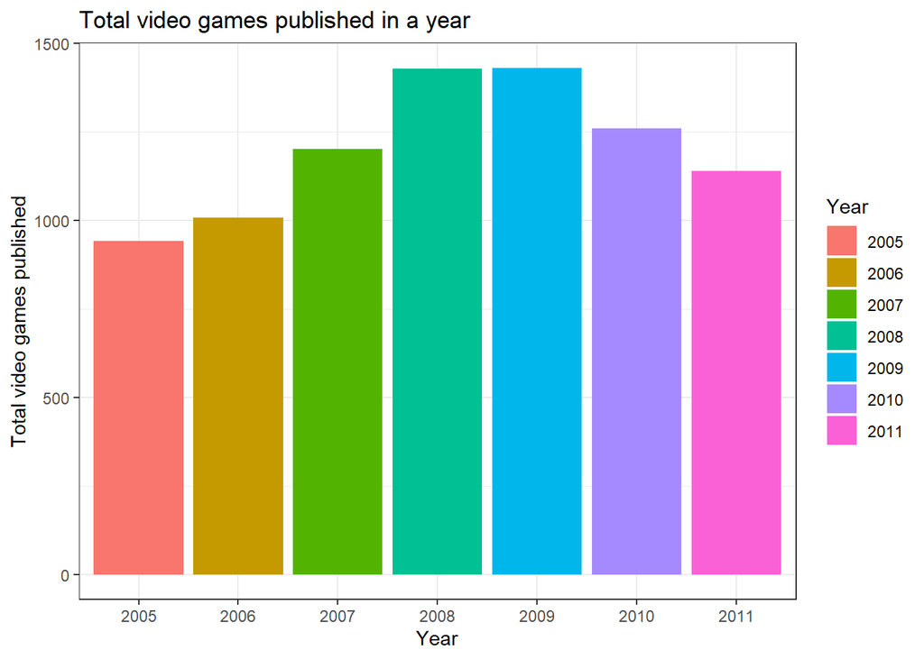

I wanted to find the most sold video game in the three regions of the world represented in the data set: North America, Europe and Japan. I wanted to see if the top sold games are the same or different in other regions of the world.

```
## [1] "North America"
```

```
##   Rank       Name Platform Year NA_Sales
## 1    1 Wii Sports      Wii 2006    41.49
```

```
## [1] "Europe"
```

```
##   Rank       Name Platform Year EU_Sales
## 1    1 Wii Sports      Wii 2006    29.02
```

```
## [1] "Japan"
```

```
##   Rank                     Name Platform Year JP_Sales
## 1    5 Pokemon Red/Pokemon Blue       GB 1996    10.22
```

Wii sports is the best sold game in both Europe and North America but not in Japan, where the most sold game is Pokemon Red/Pokemon Blue. Wii Sports is a sports video game developed and published by Nintendo for the Wii video game console. The game was released in North America along with the Wii on November 19, 2006, and was released in Japan, Australia, and Europe the following month.The game is a collection of five sports simulations, designed to demonstrate the motion-sensing capabilities of the Wii Remote. The five sports included are tennis, baseball, bowling, golf and boxing.

### Game genres with the best and least representation

For the last data exploration task I wanted to see what the genre representation looks like in the top 5 genres and the 5 least made genres. The bar chart below represents the number of games of the top 5 most represented genres of games in the data set.

```
## # A tibble: 5 x 3
##   Genre      Number Percent
##   <fct>       <int> <chr>
## 1 Puzzle        582 4%
## 2 Strategy      681 4%
## 3 Fighting      848 5%
## 4 Simulation    867 5%
## 5 Platform      886 5%
```

```
## # A tibble: 5 x 3
##   Genre        Number Percent
##   <fct>         <int> <chr>
## 1 Action         3316 20%
## 2 Sports         2346 14%
## 3 Misc           1739 10%
## 4 Role-Playing   1488 9%
## 5 Shooter        1310 8%
```

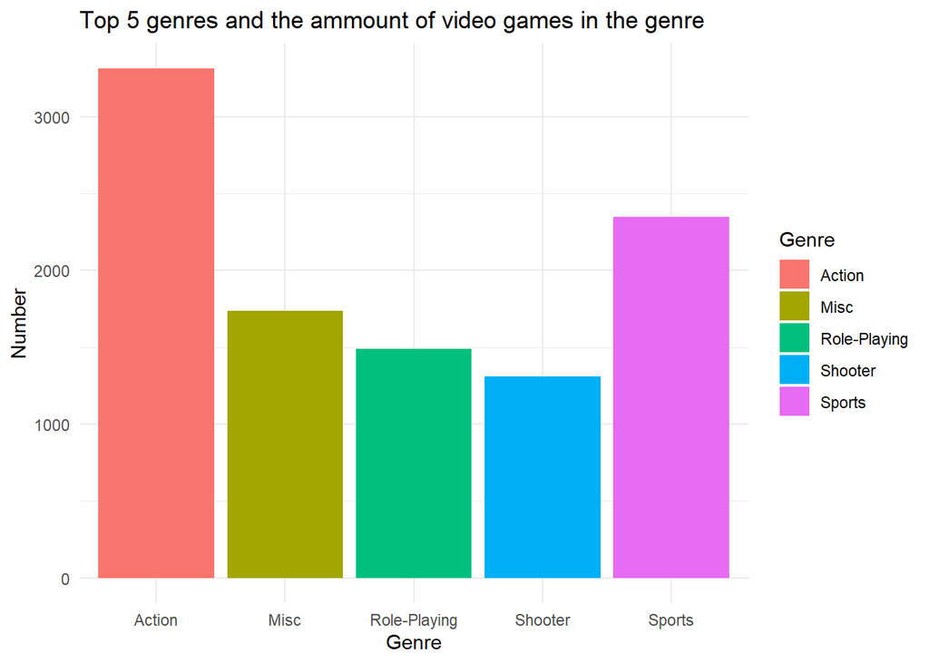

It is interesting that Puzzle and Strategy are the least favorite genre for publishers to produce games for, while action and sports game top the market. Action games take up 20% of the data set which is a pretty big percent of all the games. Following are the genres miscellaneous, role-playing and shooter. I expected sports and shooter games to be at the top as well and sure enough they came in the second and fifth place.

### Game genres that sold the most amount of copies

The previous results of the most popular genres made me want to find out if the most popular video game genres also bring in the most amount of global sales, and the following data frame and graph represents this.

```
## # A tibble: 5 x 2
##   Genre        GlobalSales
##   <fct>              <dbl>
## 1 Action             1751.
## 2 Sports             1331.
## 3 Shooter            1037.
## 4 Role-Playing        927.
## 5 Platform            831.
```

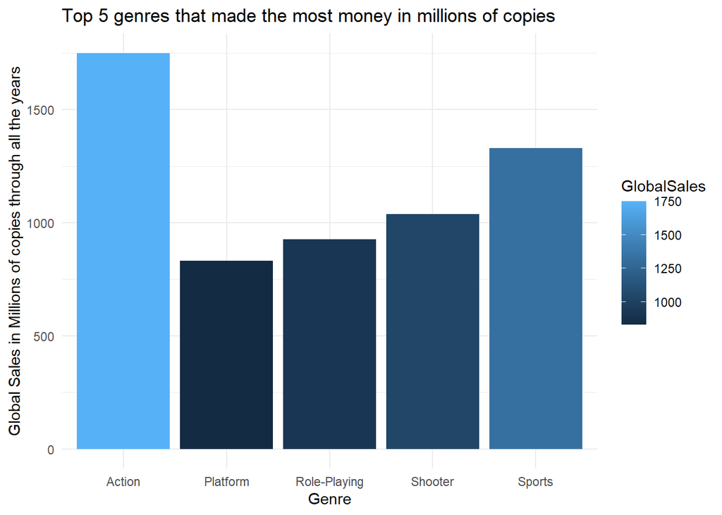

It is true that the video game genres with the most amount of games sell the most copies of games. The only difference was that the genre Platform sold more copies than the genre Miscellaneous which was in the top 5 in most games made statistic.

### Conclusion

Exploring the data set was interesting and while I am familiar with the market I found out some new things about it that I didn’t know before. It might not represent the current state because it only contains years up to 2017 but I believe it might be a very similar situation today. It was interesting to see which platforms, video game publishers and video game genres are popular and which not and what video games or genres people like the most.

### References

Gregory Smith (2016) R Studio (n.d.) Wikipedia contributors (2004)

Gregory Smith. 2016. “Video Game Sales Data Set.” https://www.kaggle.com/gregorut/videogamesales.

R Studio. n.d. “R Markdown.” https://rmarkdown.rstudio.com/.

Wikipedia contributors. 2004. “Wii Sports.” https://en.wikipedia.org/wiki/Wii_Sports.